# L13 Shiny III

Data Visualization (STAT 302)

## Overview

The goal of this lab is to reinforce and extend the `shiny` basics covered in [lesson 5](https://shiny.rstudio.com/tutorial/written-tutorial/lesson5/), [lesson 6](https://shiny.rstudio.com/tutorial/written-tutorial/lesson6/) and [part III of the webinar video](http://shiny.rstudio.com/tutorial/video/).

Building complex apps can be a daunting task. Such apps typically involve advance planning, data manipulation/restructuring, defining functions and sub-routines (“helper functions”), computing/resource allocation decisions, and the process is almost never linear in nature. One should always try to think several steps ahead or even plan for future adjustments (i.e. efficient coding). Obviously, building complex shiny apps requires a deep understanding of how to construct plots/graphics in R. Fortunately, we spent the first part of the course developing a deep understanding of `ggplot2`. The goal of this lab is to leverage this knowledge to build/mimic a moderately complex app.

## Dataset

To complete this lab we require the `counties.rds` dataset contained in the `UScensus2010` R package. This dataset is described in [lesson 5](https://shiny.rstudio.com/tutorial/written-tutorial/lesson5/).

## Submission Guidelines

You will be submitting a zip file that contains all app directories (each app gets a directory/file). See the **shiny App Labs** page on Canvas for complete instructions. Please **only** include shiny app directories/files. The zip file should follow our standard naming convention (e.g. **Kuyper_Arend_L12.zip**.

## Exercises

Complete the following exercises.

### Exercise 1

Work through [lesson 5](https://shiny.rstudio.com/tutorial/written-tutorial/lesson5/) and [lesson 6](https://shiny.rstudio.com/tutorial/written-tutorial/lesson6/) which both contain an exercise for practice. The lessons guide you through the construction of two moderately complex apps and contain a few exercises during the process. Please submit both the `census-app` and `stockVis` apps. **Don’t have to convert to ggplot2 code** — will be doing that in later exercises.

### Exercise 2

Create a copy of the `census-app` directory/file and rename it `census-app-ggplot2`. We are going to use this as a starting point to build a moderately complex app using `gpplot2`. We will also add a widget that allows users to select one of the 48 contiguous states to explore. A few pictures of the app are provided below for reference, but for a closer look go to https://amkuyper.shinyapps.io/census-app-ggplot2/.

[figure not shown]

[figure not shown]

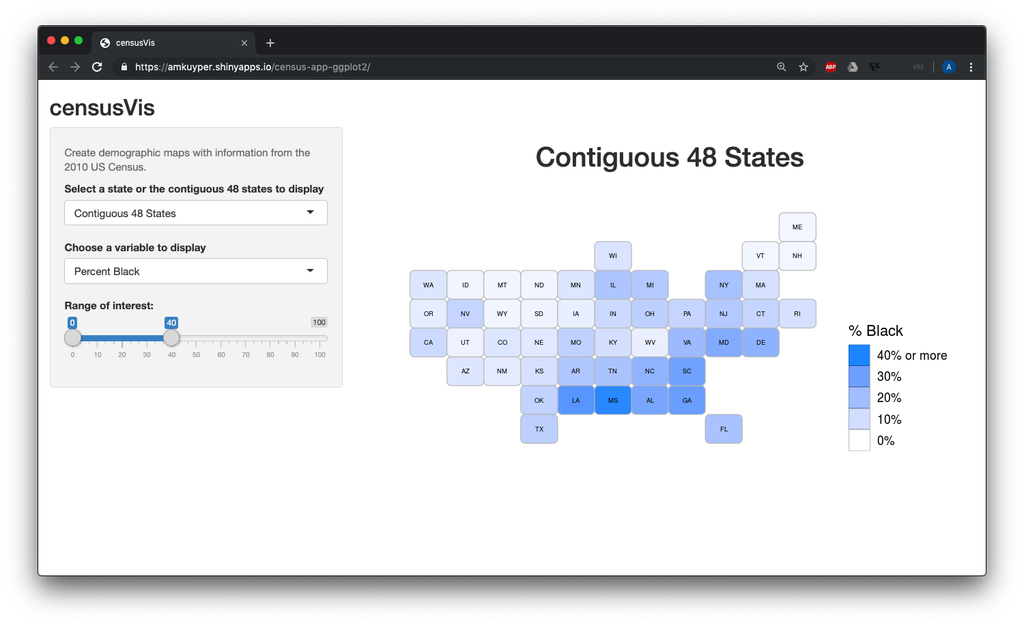

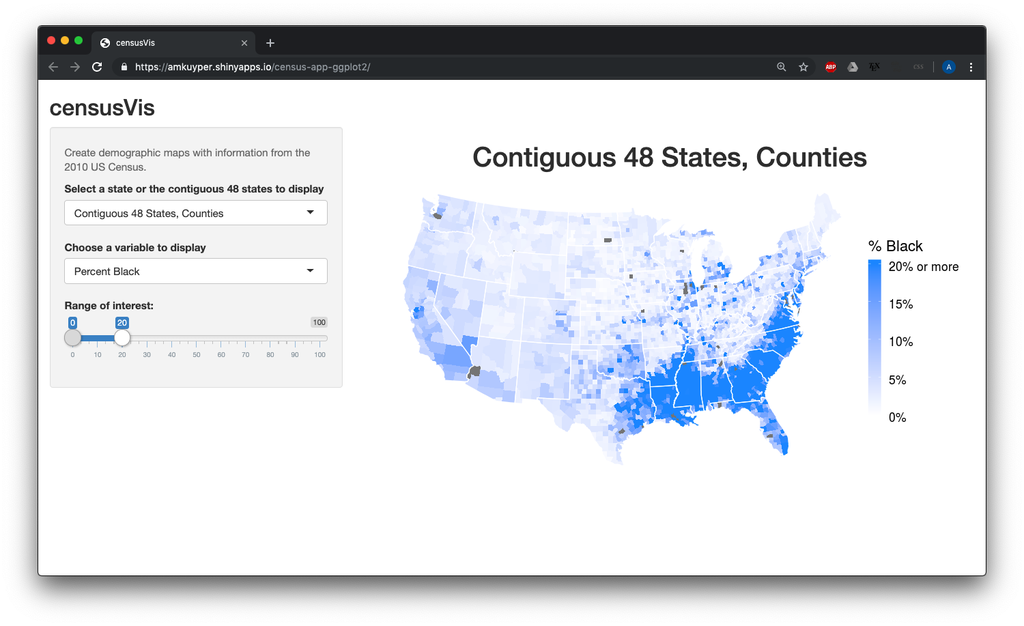

## Challenge

Create a copy of `stockVis` and rename it `stockVis-ggplot2`. As you did in Exercise 2 above, convert the graphic/plot code to `ggplot2` code. In addition make any alterations you might find interesting. An example is pictured below and can be explored by going to https://amkuyper.shinyapps.io/stockVis-ggplot2/.

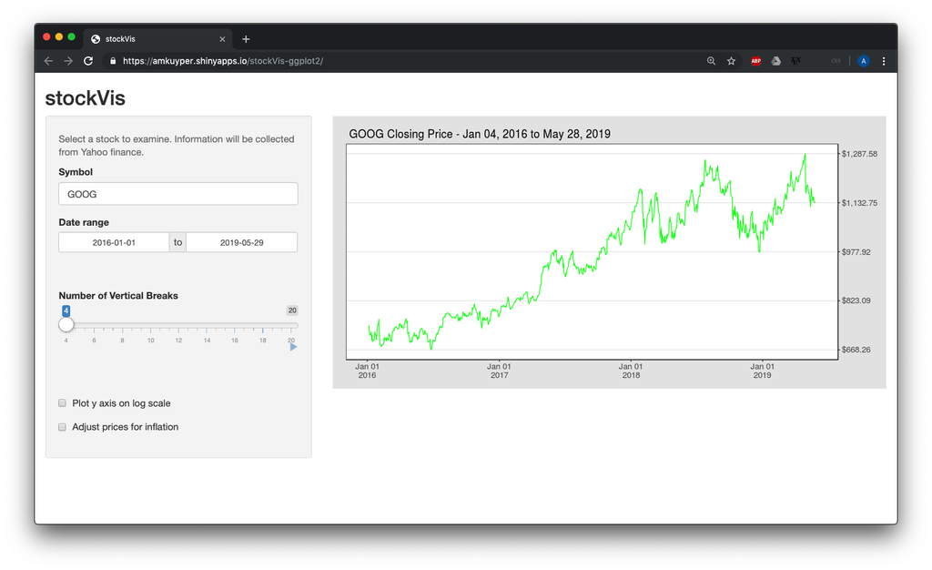

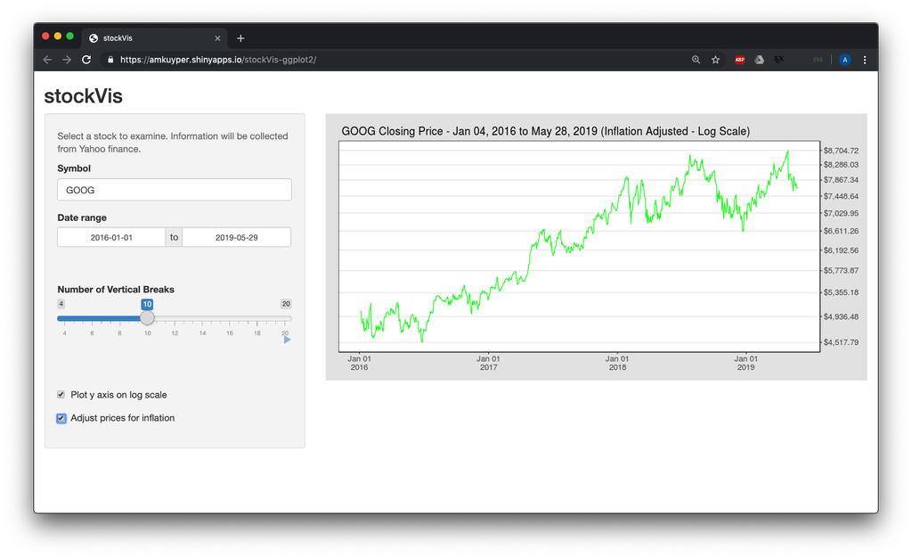